# trabajo grupal- Jazmin Esteban

Estadística para el Análisis Político 2

24/11/21

```r
library(rio)
library(ggplot2) #para hacer gráficos
library(Hmisc)   #para correlación
library(nortest)
library(lm.beta)
library(car)
```

=================================================================

# **Caso de estudio: Nivel de pobreza en el Perú a nivel de distritos**

El propósito del estudio se realiza con el fin de identificar como se distribuye el nivel de pobreza en el Perú, a nivel de distritos, a partir de diferentes aristas: condición de vivienda, nivel educativo, programas sociales y los servicios que cuentan.

En este caso, se realiza un enfoque en cuanto a vivienda. Es decir, se estudiara la condición dentro de la vivienda con que cuenta la población para realizar sus diferentes actividades. De acuerdo con ello, se evaluara el porcentaje de pobreza(variable dependiente) según el abastecimiento de agua y el consumo de energía domestica por vivienda (variables independientes). Asimismo,se utilizara el porcentaje de la población, en cien mil, como variable control.

Para ello, las hipótesis que se plantean son:

- H1: El porcentaje de pobreza responde bajo criterios de abastecimiento de agua mediante la red publica por vivienda
- H2: El porcentaje de pobreza responde bajo criterios de consumo de leña como combustible de cocina por vivienda

*Preparación de los datos*

```r
data="https://github.com/jazzz12/Trabajo-Grupal/blob/main/base_de_datos.xlsx?raw=true"
data= import(data)
```

```r
str(data)
```

```
## 'data.frame':    1874 obs. of  6 variables:
##  $ Codigo      : num  10101 10102 10103 10104 10105 ...
##  $ Distrito    : chr  "Amazonas, Chachapoyas, distrito: Chachapoyas" "Amazonas, Chachapoyas, distrito: Asunción" "Amazonas, Chachapoyas, distrito: Balsas" "Amazonas, Chachapoyas, distrito: Cheto" ...
##  $ porpobre    : num  9.03 36.52 45.73 39.17 53.05 ...
##  $ redpublica  : num  83.5 98 45.3 87.3 21.6 ...
##  $ leña        : num  24.6 94.2 85.4 81.8 95.6 ...
##  $ poblacienmil: num  0.32589 0.00262 0.01136 0.00642 0.00585 ...
```

```r
names(data)
```

```
## [1] "Codigo"       "Distrito"     "porpobre"     "redpublica"   "leña"
## [6] "poblacienmil"
```

```r
data$poblacienmil= as.numeric(data$poblacienmil)
```

*Limpiando un poco la base de datos:*

```r
library(stringr)
data[1,2]
```

```
## [1] "Amazonas, Chachapoyas, distrito: Chachapoyas"
```

```r
data$Codigo= stringr::str_pad(data$Codigo, 6, side = "left", pad =0)
```

```r
head(data)
```

```
##   Codigo                                     Distrito  porpobre redpublica
## 1 010101 Amazonas, Chachapoyas, distrito: Chachapoyas  9.034625   83.45343
## 2 010102    Amazonas, Chachapoyas, distrito: Asunción 36.519949   98.00000
## 3 010103      Amazonas, Chachapoyas, distrito: Balsas 45.732962   45.34535
## 4 010104       Amazonas, Chachapoyas, distrito: Cheto 39.169782   87.26415
## 5 010105   Amazonas, Chachapoyas, distrito: Chiliquin 53.045662   21.56863
## 6 010106 Amazonas, Chachapoyas, distrito: Chuquibamba 51.607832   64.08318
##       leña poblacienmil
## 1 24.62017      0.32589
## 2 94.23077      0.00262
## 3 85.35211      0.01136
## 4 81.81818      0.00642
## 5 95.63107      0.00585
## 6 96.13971      0.01781
```

*Representación de las hipótesis:*

- H1: “El porcentaje de pobreza responde bajo criterios de abastecimiento de agua mediante la red publica por vivienda” ,controlando por “el tamaño de la población”.Esto se figuaria de la siguiente manera:

```r
modelo1= lm(porpobre ~redpublica + poblacienmil, data = data)
summary(modelo1)
```

```
##
## Call:
## lm(formula = porpobre ~ redpublica + poblacienmil, data = data)
##
## Residuals:
##     Min      1Q  Median      3Q     Max
## -44.710 -10.250   0.079  10.218  41.891
##
## Coefficients:
##              Estimate Std. Error t value Pr(>|t|)
## (Intercept)  56.86288    1.02974   55.22   <2e-16 ***
## redpublica   -0.27135    0.01268  -21.39   <2e-16 ***
## poblacienmil -5.60810    0.41880  -13.39   <2e-16 ***
## ---
## Signif. codes:  0 '***' 0.001 '**' 0.01 '*' 0.05 '.' 0.1 ' ' 1
##
## Residual standard error: 14.78 on 1869 degrees of freedom
##   (2 observations deleted due to missingness)
## Multiple R-squared:  0.2345, Adjusted R-squared:  0.2336
## F-statistic: 286.2 on 2 and 1869 DF,  p-value: < 2.2e-16
```

```r
library(stargazer)
reg1= lm(modelo1, data = data)
stargazer(reg1, type = "html",intercept.bottom = FALSE, style="all2")
```

|  | *Dependent variable:* |
| --- | --- |
|  | porpobre |
| Constant | 56.863*** |
|  | (1.030) |
| redpublica | -0.271*** |
|  | (0.013) |
| poblacienmil | -5.608*** |
|  | (0.419) |
| Observations | 1,872 |
| R<sup>2</sup> | 0.234 |
| Adjusted R<sup>2</sup> | 0.234 |
| Residual Std. Error | 14.777 (df = 1869) |
| F Statistic | 286.219*** (df = 2; 1869) (p = 0.000) |
| *Note:* | p<0.1; p<0.05; p<0.01 |

Viendo la regresión, se puede estimar que redpublica tiene un efecto significativo al 0.1; asimismo, tiene un efecto inversamente proporcional, ya que el coeficiente calculado es negativo; y, por ultimo, su magnitud es de -0.271,es decir, lo que varía porpobre en promedio cuando redpublica se incremente en una unidad, controlando por poblacienmil.

Se puede representar esa relación mediante una ecuación:

#### porpobre= 56.863+-0.27135.redpublica+-5.60810⋅poblacioncienmil+ϵ

Adicional mente, se brinda una estimación del R cuadrado ajustado (0.2336) que nos aproxima un porcentaje de una pista posible a la escenario que se quiere evaluar

Pero,*¿Si evaluamos bajo el consumo de leña como combustible?…*

- H2: El porcentaje de pobreza responde bajo criterios de consumo de leña como combustible de cocina por vivienda

```r
modelo2= lm(porpobre ~redpublica + leña + poblacienmil , data=data)
summary(modelo2)
```

```
##
## Call:
## lm(formula = porpobre ~ redpublica + leña + poblacienmil, data = data)
##
## Residuals:
##     Min      1Q  Median      3Q     Max
## -41.057  -8.982  -0.672   7.814  50.509
##
## Coefficients:
##              Estimate Std. Error t value Pr(>|t|)
## (Intercept)  29.74641    1.39220  21.367  < 2e-16 ***
## redpublica   -0.19094    0.01140 -16.748  < 2e-16 ***
## leña          0.26265    0.01038  25.307  < 2e-16 ***
## poblacienmil -2.00540    0.38852  -5.162 2.71e-07 ***
## ---
## Signif. codes:  0 '***' 0.001 '**' 0.01 '*' 0.05 '.' 0.1 ' ' 1
##
## Residual standard error: 12.76 on 1868 degrees of freedom
##   (2 observations deleted due to missingness)
## Multiple R-squared:  0.4299, Adjusted R-squared:  0.429
## F-statistic: 469.6 on 3 and 1868 DF,  p-value: < 2.2e-16
```

```r
reg2= lm(modelo2, data = data)
stargazer(reg2, type = "html",intercept.bottom = FALSE, style= "all2")
```

|  | *Dependent variable:* |
| --- | --- |
|  | porpobre |
| Constant | 29.746*** |
|  | (1.392) |
| redpublica | -0.191*** |
|  | (0.011) |
| leña | 0.263*** |
|  | (0.010) |
| poblacienmil | -2.005*** |
|  | (0.389) |
| Observations | 1,872 |
| R<sup>2</sup> | 0.430 |
| Adjusted R<sup>2</sup> | 0.429 |
| Residual Std. Error | 12.755 (df = 1868) |
| F Statistic | 469.570*** (df = 3; 1868) (p = 0.000) |
| *Note:* | p<0.1; p<0.05; p<0.01 |

Al igual que el anterior modelo, al probar esta hipótesis vemos, que redpublica también tiene efecto significativo al 0.1 ; ese efecto es inverso, pues el coeficiente calculado es negativo; y la magnitud de ese efecto es -0.191, lo que indica cuanto varía porpobre en promedio cuando redpublica se incremente en una unidad, controlando por poblacienmil.

Pero, vemos que leña tiene efecto significativo al 0.001 ; ese efecto es directo, pues el coeficiente calculado es positivo; y la magnitud de ese efecto es 0.263, lo que indica cuanto varía porpobre en promedio cuando leña aumenta en una unidad (también controlado por poblacienmil).

Hemos podido percibir dos modelos que nos permitian brindar los escenarios esperados; no obstante, se escogerá uno de ellos. Para ello, se empleara la tabla anova que nos permite ver la diferencia significativa entre ambos modelos.

*H0= Existe una igualdad de varianzas entre las medias grupales de ambos modelos*

**tabla de de análisis de variaran**

```r
tanova= anova(reg1, reg2)
stargazer(tanova,type='html',summary = F,title = "Table de Análisis de Varianza")
```

**Table de Análisis de Varianza**

|  | Res.Df | RSS | Df | Sum of Sq | F | Pr(> F) |
| --- | --- | --- | --- | --- | --- | --- |
| 1 | 1,869 | 408,107.200 |  |  |  |  |
| 2 | 1,868 | 303,913.100 | 1 | 104,194.100 | 640.428 | 0 |

A través de la tabla anova, podemos contrastar la hipótesis nula planteada. Ademas, se muestra que el modelo 2 reduce el error al incluir una variable mas (es decir, ambas variables independientes). Por ello, se escogerá el modelo 2

```r
library(stargazer)
```

```r
stargazer(reg1,reg2, type ="text")
```

```
##
## =======================================================================
##                                     Dependent variable:
##                     ---------------------------------------------------
##                                          porpobre
##                                (1)                       (2)
## -----------------------------------------------------------------------
## redpublica                  -0.271***                 -0.191***
##                              (0.013)                   (0.011)
##
## leña                                                  0.263***
##                                                        (0.010)
##
## poblacienmil                -5.608***                 -2.005***
##                              (0.419)                   (0.389)
##
## Constant                    56.863***                 29.746***
##                              (1.030)                   (1.392)
##
## -----------------------------------------------------------------------
## Observations                  1,872                     1,872
## R2                            0.234                     0.430
## Adjusted R2                   0.234                     0.429
## Residual Std. Error    14.777 (df = 1869)        12.755 (df = 1868)
## F Statistic         286.219*** (df = 2; 1869) 469.570*** (df = 3; 1868)
## =======================================================================
## Note:                                       *p<0.1; **p<0.05; ***p<0.01
```

Es posible realizar una comparación entre ambos modelos. De acuerdo a ello, indica que el modelo dos tiene un grado de significancia mayor por el aumento de una variable al modelo. Debido a que, el 42,9% del porcentaje de la variabilidad de porpobre es predicho por redpublica y leña, segun su r ajustado.

=================================================================

Teniendo definido al modelo de regresión, se debe verificar si se encuentra adecuado para el estudio del caso.

# Diagnostico

### `linealidad`

Se asume relación lineal entre Y y Xs:

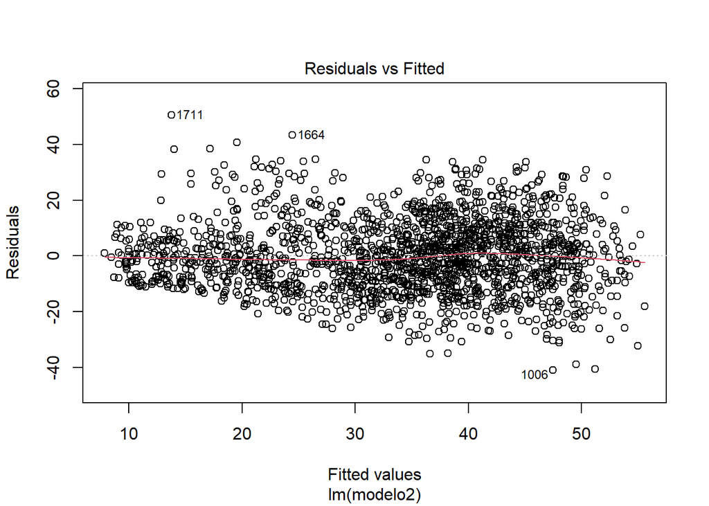

```r
plot(reg2, 1)
```

- Según la gráfica de dispersión de los valores predichos y los residuos, se muestra, aparentemente, que se cumple un supuesto de linealidad. La linea roja se encuentra de manera horizontal.Por lo que, la variable porpobre esta lineal mente relacionada con las variables redpublica y leña

### `Homocedasticidad`

Se asume que el error del modelo de regresión no afecta a la varianza o dispersión de la estimación

*H0= la varianza de los errores es la misma para cualquier combinación de los valores de las variables independientes*

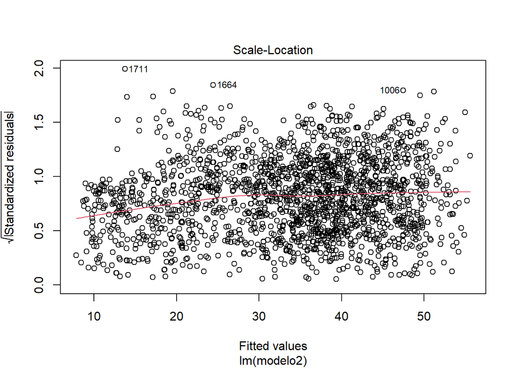

```r
plot(reg2, 3)
```

```r
library(lmtest)
bptest(reg2)
```

```
##
##  studentized Breusch-Pagan test
##
## data:  reg2
## BP = 93.999, df = 3, p-value < 2.2e-16
```

Es un valor significativo; pero, la probabilidad de homocedasticidad es muy baja (p-value menor a 0.05) y puede que los errores se distribuyen normalmente.

### `Normalidad de residuos`

Los residuos, la diferencia entre porpobre y $\hat{porpobre}$, deben distribuirse de manera normal:

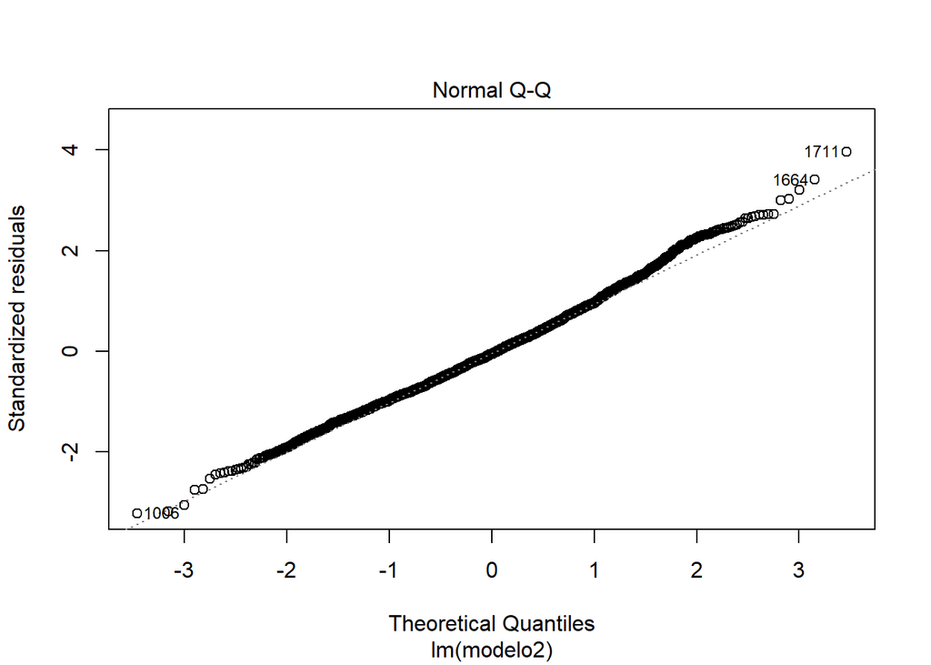

```r
plot(reg2, 2)
```

- Se puede apreciar que los residuos no se destruyen; por lo que, aparentemente se presenta una distribución normal

Realizamos la prueba de normalidad Shapiro- wilk para verificar

*H0: La distribución es normal H1: La distribución no es normal*

```r
shapiro.test(reg2$residuals)
```

```
##
##  Shapiro-Wilk normality test
##
## data:  reg2$residuals
## W = 0.9951, p-value = 8.058e-06
```

Podemos observar que si existe diferencias significativas con la distribución (p-value<0.05); por lo tanto, rechazamos a nuestra hipótesis nula. Presentamos una distribución no normal

### `no multicolinealidad`

Si los predictores tienen una correlación muy alta entre sí, hay multicolinealidad, lo cual no es deseable:

```r
library(DescTools)
VIF(reg2) # > 5 es problematico(retirarlo del estudio)
```

```
##   redpublica         leña poblacienmil
##     1.102691     1.213308     1.174753
```

### `influyentes`

Hay casos particulares, que tienen la capacidad de influir lo que el modelo representa. A veces es mejor detectarlos y,en lo posible, suprimiéndolos:

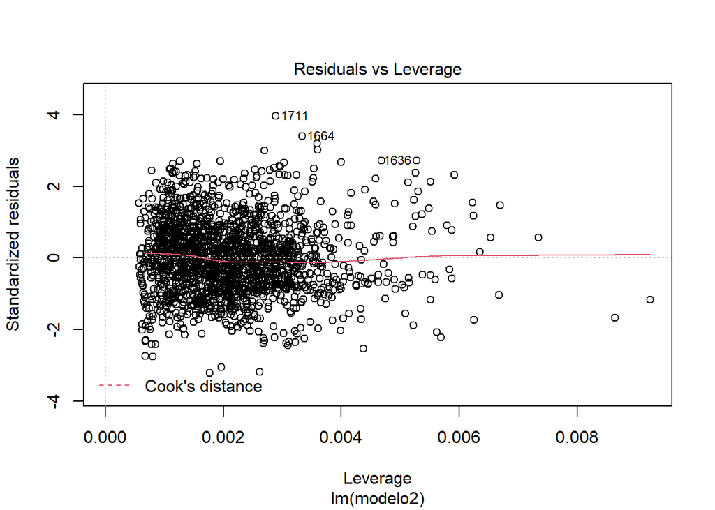

```r
plot(reg2, 5)
```

Viendo a la gráfica, no se presenta un valores extremadamente atípicos que puedan influir severamente al modelo. Pero, es pertinente recuperar los posibles casos influyentes:

```r
checkreg2=as.data.frame(influence.measures(reg2)$is.inf)
head(checkreg2)
```

```
##   dfb.1_ dfb.rdpb dfb.leña dfb.pblc dffit cov.r cook.d   hat
## 1  FALSE    FALSE    FALSE    FALSE FALSE FALSE  FALSE FALSE
## 2  FALSE    FALSE    FALSE    FALSE FALSE FALSE  FALSE FALSE
## 3  FALSE    FALSE    FALSE    FALSE FALSE FALSE  FALSE FALSE
## 4  FALSE    FALSE    FALSE    FALSE FALSE FALSE  FALSE FALSE
## 5  FALSE    FALSE    FALSE    FALSE FALSE FALSE  FALSE FALSE
## 6  FALSE    FALSE    FALSE    FALSE FALSE FALSE  FALSE FALSE
```

#### *Observaciones extremas respecto a x: valor de distancia*

1. Distancia cook: mide la influencia de cada observación en el modelo
2. hatvalue: las predicciones hechas por el modelo para cada observación.

```r
checkreg2[checkreg2$cook.d & checkreg2$hat,]
```

```
## [1] dfb.1_   dfb.rdpb dfb.leña dfb.pblc dffit    cov.r    cook.d   hat
## <0 rows> (or 0-length row.names)
```

Se puede apreciar que no se ha detectado valores que afecten la regresión. En conclusión, el modelo 2 presenta ser un buen modelo para la investigación de la pobreza en base a las condiciones de viviendas.

Hemos visto que el modelo presenta linealidad entre las variables independientes (redpublica y leña) con la dependiente (porpobre). Es decir, que existe una relación lineal (correctamente especificado) entre abastecimiento de agua y consumo de leña como energía en el porcentaje de pobreza. No obstante, presenta una homocedasticidad baja y una distribución no normal (aunque esto ultimo depende, ya que al ser un tamaño muestral tan grande, tiende a no ser normal) .A pesar de esto, los problemas de la homocedasticidad y de distribución normal pueden tener consecuencias muy leves al modelo.En cuanto al supuesto de no multicolinealidad, lo llega a cumplir, no presenta una relación de dependencia entre las variables explicativas (incluyendo a la variable de control) que puede ser perjudicial al modelo.Por ultimo, no se ha presentado valores influyentes o atípicos extremos que puedan tener un mayor peso en la formulación del modelo y distorsionarlo.